##### Auteur: KABRE Roland

##### Ingénieur statisticien économiste

# Text mining

### Introduction

La pauvreté en Afrique est un sujet central dans la recherche scientifique, abordé sous dives angles économiques socianx et politiques. Pour mieux comprendre les tendances et orientations des études sur ce thème, nous avons collecté **300 résumés d’articles scientifiques** en utilisant le web scraping. Cette technique permet d’extraire automatiquement du texte à partir de source s en ligne, offrant ainsi un accès à un large corpus de publications.  
L’analyse de ce corpus vise à identifier les principales thématiques abordées, le ton général des travaux ainsi que les perspectives mises en avant. Cette approche permettra de mieux cerner l’évolution des recherches sur la pauvreté et d’identifier d’éventuelles lacunes.

#### Importation des bibiothèques

Avant de procéder à l’analyse de texte, nous devons importer les bibliothèques nécessaires. Ces bibliothèques nous permettront d’effectuer différentes tâches comme le nettoyage des textes, la tokenisation, l’analyse de sentiment et la modélisation des sujets.  
Nous allons maintenant charger les packages essentiels pour le text mining dans R.

```r
library(tidyverse)
library(tidytext)
library(tm)
library(maps)
library(SnowballC)
library(wordcloud)
library(topicmodels)
library(dplyr)
library(knitr)
library(ggplot2)
library(reshape2)
library(igraph)
library(ggraph)
```

#### Chargement des données

Après avoir effectué le web scraping des articles, nous avons sauvegardé les données dans un fichier CSV.  
Nous allons maintenant importer ce fichier afin de procéder à l’analyse de texte. Cette étape nous permettra d’explorer et de préparer les données pour les prochaines analyses.

```r
data<-read.csv("C:/Users/USER/Desktop/django/article.csv")
d<-data %>% # Selection de la colonne contenant les résumes d'articles
  select("all_abstracts")

v_text <- data.frame(text = d) # Transformation des résumés en dataframe
nrow(v_text)
```

[1] 300

Nous avons 300 résumés d’articles

#### Préparation des données textuelles

Avant d’effectuer l’analyse textuelle, nous devons transformer nos données brutes en un format exploitable.  
Cette étape consiste à tokeniser les textes, c’est-à-dire à les découper en unités plus petites (mots), tout en conservant l’ordre des lignes pour une meilleure traçabilité.

```r
v_tidy_data<-v_text %>%
  mutate(linenumber = row_number()) %>%
  ungroup() %>%
  unnest_tokens(word, all_abstracts)
```

### Nettoyage des données textuelles

Avant de procéder à l’analyse plus approfondie des données textuelles, il est nécessaire de les **nettoyer** pour s’assurer que seules les informations pertinentes sont prises en compte. Cette étape de nettoyage inclut plusieurs tâches essentielles, comme l’élimination des mots inutiles, la suppression des chiffres, la gestion des espaces indésirables, et le **stemming**.

### Les étapes de nettoyage incluent :

Ces étapes permettent d’assurer que les données sont prêtes pour une analyse plus significative et d’éviter que des éléments non pertinents n’affectent les résultats.

```r
v_tidy_data <-
  v_tidy_data %>%
  anti_join(stop_words) # Elimination des mots inutiles

mot_inutile <- data.frame(word = c("https", "e.g", "africa", "poverty", "africa"))
v_tidy_data <-
  v_tidy_data %>%
  anti_join(mot_inutile) # Elimination de quelques mots inutiles restants
# Enlever les chiffres
v_tidy_data <-
  v_tidy_data %>%
  filter(!grepl("\\b\\d+\\b", word))

# Enlever les espaces
v_tidy_data <-
  v_tidy_data %>%
  mutate(word = gsub("\\s+","", word))

# Stemming
v_tidy_data <- v_tidy_data %>%
  mutate_at("word", funs(wordStem((.), language="en")))
```

#### Analyse des mots les plus fréquents après nettoyage

Une fois les données textuelles nettoyées, nous pouvons analyser les mots les plus fréquents dans le corpus. En éliminant les mots inutiles, les chiffres, et en appliquant le **stemming**, nous nous assurons que l’analyse est concentrée sur les termes significatifs. Cela permet d’identifier les mots clés qui émergent du texte après avoir éliminé le bruit lié aux mots courants et aux éléments non pertinents.

```r
library(knitr)
top_words <- v_tidy_data %>%
  count(word) %>%
  arrange(desc(n)) %>%
  head(10)

# Affichage sous forme de tableau
kable(top_words, col.names = c("Mot", "Fréquence"), caption = "Les 10 mots les plus fréquents")
```

Les 10 mots les plus fréquents

| Mot | Fréquence |
| --- | --- |
| south | 60 |
| health | 58 |
| studi | 49 |
| saharan | 48 |
| countri | 44 |
| africa | 36 |
| household | 31 |
| develop | 29 |
| econom | 29 |
| polici | 28 |

##### Analyse préliminaire des mots les plus fréquents

Les 10 mots les plus fréquents révèlent des thèmes importants qui méritent d’être explorés plus en détail. On observe une forte présence de termes géographiques et régionaux tels que **“south”** et **“saharan”**, ainsi que des sujets liés à la santé, le développement et l’économie (**“health”**, **“develop”**, **“econom”**). Des mots comme **“studi”** et **“countri”** indiquent aussi un possible focus sur des recherches et des contextes nationaux. Ces résultats nous offrent une première vue d’ensemble des thématiques dominantes dans le corpus, mais un examen plus approfondi sera nécessaire pour mieux comprendre les liens entre ces termes.

###### Représentation Graphique

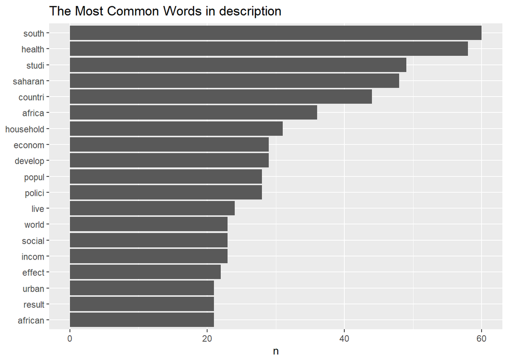

```r
# graphique des mots les plus utilise dans tout le document
v_tidy_data %>%
  count(word, sort = TRUE) %>%
  filter(n > 20) %>%
  mutate(word = reorder(word, n)) %>%
  ggplot(aes(word, n)) +
  geom_col() +
  xlab(NULL) +
  coord_flip() +
  ggtitle("The Most Common Words in description")
```

###### Le nuage de mots

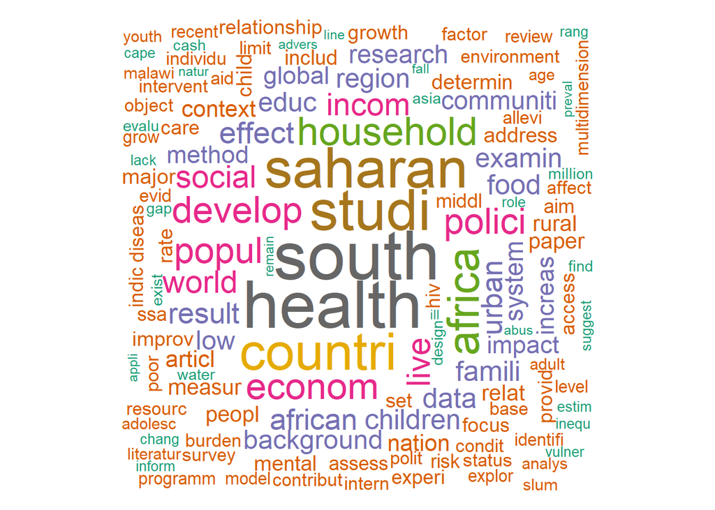

```r
# nuage de mots
v_word_count <- v_tidy_data %>%
  count(word, sort = TRUE)

wordcloud(words = v_word_count$word, freq = v_word_count$n,
          min.freq = 1,
          max.words = 200,
          random.order=FALSE,
          colors=brewer.pal(8, "Dark2"))
```

### Analyse des sentiments du corpus

Dans cette section, nous appliquons une analyse de sentiment en utilisant le lexique **Bing**. L’objectif est d’identifier et de quantifier les mots à connotation **positive** et **négative** présents dans le texte.

Nous commençons par extraire uniquement les mots associés à un sentiment **positif**, puis nous analysons la distribution globale des sentiments dans le corpus. Ensuite, nous examinons l’évolution des sentiments sur l’ensemble du texte en regroupant les mots par blocs de 10 lignes. Enfin, nous calculons un **score de sentiment**, défini comme la différence entre le nombre de mots positifs et négatifs dans chaque bloc, afin d’obtenir une vision globale de la tonalité du texte.

```r
positive_sentiment <- get_sentiments("bing") %>%
  filter(sentiment == "positive")

words<-v_tidy_data %>%
  semi_join(positive_sentiment) %>%
  count(word, sort = TRUE)

v_text_sentiments <- v_tidy_data %>%
  inner_join(get_sentiments("bing"))

v_text_sentiment <- v_tidy_data %>%
  inner_join(get_sentiments("bing")) %>%
  count(index = linenumber %/% 10, sentiment)

v_text_sentimentss <- v_tidy_data %>%
  inner_join(get_sentiments("bing")) %>%
  count(index = linenumber %/% 10, sentiment) %>%
  spread(sentiment, n, fill = 0)

v_text_sentimentsss <- v_tidy_data %>%
  inner_join(get_sentiments("bing")) %>%
  count(index = linenumber %/% 10, sentiment) %>%
  spread(sentiment, n, fill = 0) %>%
  mutate(sentiment = positive - negative)
```

**La répartition des sentiments montre une nette prédominance des termes négatifs , ce qui est cohérent avec la thématique abordée. Les articles analysés traitant de la pauvreté en Afrique , contiennent naturellement un vocabulaire associé aux défis, inégalités et difficultés socio-économiques, entraînant ainsi cette tonalité globale.**

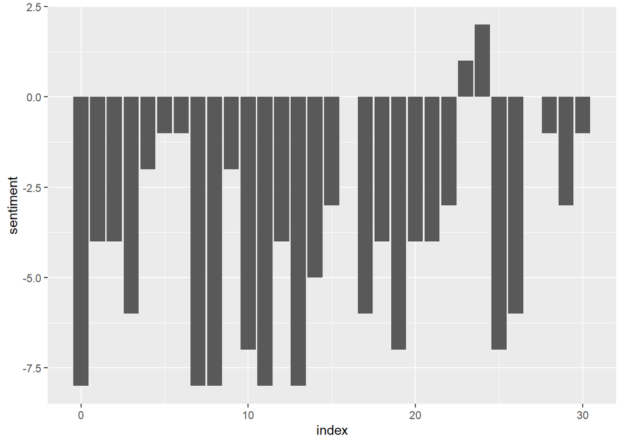

```r
ggplot(v_text_sentimentsss, aes(index, sentiment)) + geom_bar(stat ="identity", show.legend = TRUE)
```

#### Contribution des mots à l’analyse de sentiment

Afin de mieux comprendre l’impact de chaque mot sur la tonalité globale du texte, nous comptabilisons la fréquence des termes associés aux sentiments **positifs** et **négatifs** selon le lexique Bing. Cela nous permet d’identifier quels mots influencent le plus la perception du corpus.

```r
# contribution de chaque mot dans le sentiment
v_word_counts <- v_tidy_data %>%
  inner_join(get_sentiments("bing")) %>%
  count(word, sentiment, sort = TRUE)
```

##### Visualisation de la contribution des mots aux sentiments

Pour mieux interpréter la répartition des sentiments, nous représentons graphiquement les mots ayant le plus contribué aux sentiments **positifs** et **négatifs**. Cette visualisation met en évidence les termes les plus influents et leur impact sur la tonalité globale du corpus.

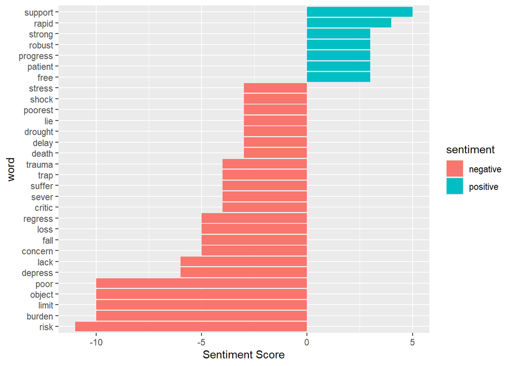

```r
# representation graphique de la contribution des mots de chaque sentiment
v_word_counts %>%
  filter(n > 2) %>%
  mutate(n = ifelse(sentiment == "negative", -n, n)) %>%
  mutate(word = reorder(word, n)) %>%
  ggplot(aes(word, n, fill = sentiment))+
  geom_col() +
  coord_flip() +
  labs(y = "Sentiment Score")
```

##### Visualisation des mots par sentiment à l’aide d’un nuage de mots

Nous allons maintenant visualiser la fréquence des mots associés aux sentiments **positifs** et **négatifs** sous forme de nuage de mots. Cette représentation graphique permet de mettre en évidence les termes les plus utilisés dans chaque catégorie sentimentale, facilitant ainsi l’interprétation visuelle des contributions de chaque mot.

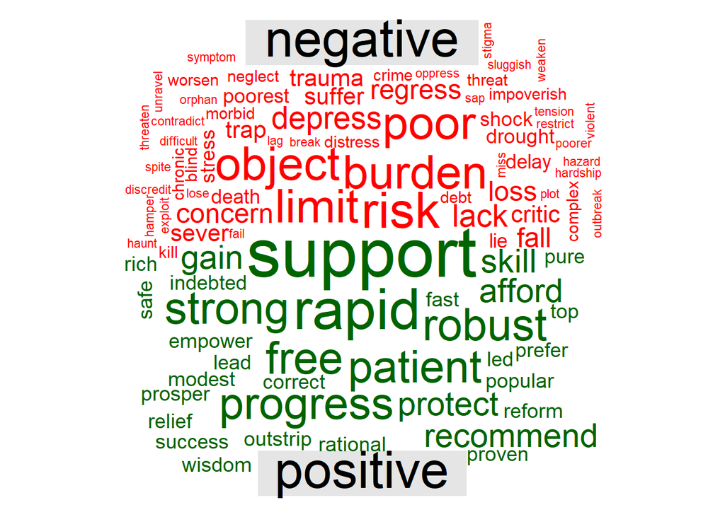

```r
library(reshape2)

positif_negatif<-v_tidy_data %>%
  inner_join(get_sentiments("bing")) %>%
  count(word, sentiment, sort = TRUE) %>%
  acast(word ~ sentiment, value.var = "n", fill = 0)

v_tidy_data %>%
  inner_join(get_sentiments("bing")) %>%
  count(word, sentiment, sort = TRUE) %>%
  acast(word ~ sentiment, value.var = "n", fill = 0) %>%
  comparison.cloud(colors = c("red", "dark green"), max.words = 100)
```

### Analyse des émotions

Dans cette étape, nous allons explorer les émotions exprimées dans les articles traitant de la pauvreté en Afrique en utilisant un lexique spécialisé. Cette analyse nous permettra de mieux comprendre les sentiments sous-jacents, au-delà des simples catégories positives et négatives, et d’identifier des émotions spécifiques liées à cette problématique.

##### Regroupement des émotions positives et négatives dans les articles sur la pauvreté en Afrique

Dans cette étape, nous allons identifier et regrouper les émotions **positives** et **négatives** présentes dans les articles traitant de la pauvreté en Afrique en utilisant le dictionnaire **NRC**. Nous filtrerons les mots en fonction de ces émotions et calculerons leur fréquence pour évaluer la tonalité émotionnelle du corpus. Cette analyse nous permettra de mieux cerner les émotions dominantes dans les textes et leur impact sur la perception de la pauvreté en Afrique.

```r
# on regroupe les emotions positives et négatives
v_positive_emotions <-c("positive","joy","anticipation","surprise","trust")
v_negative_emotions <-c("negative","anger","disgust","fear","sadness")

# ici nous utilisons le dictionnaire nrc
v_lexicon <- "nrc"


#visualisation du dictionnaire nrc
get_sentiments(v_lexicon)
```

# A tibble: 13,872 × 2

word sentiment  
1 abacus trust  
2 abandon fear  
3 abandon negative 4 abandon sadness  
5 abandoned anger  
6 abandoned fear  
7 abandoned negative 8 abandoned sadness  
9 abandonment anger  
10 abandonment fear  
# ℹ 13,862 more rows

```r
# on filtre les lignes dont les sentiment sont contenu dans
#notre v_positive_emotion
v_positive_sentiment <- get_sentiments(v_lexicon) %>%
  filter(sentiment %in% v_positive_emotions)


# on va retenir les mots de notre tidydata dont le sentiment est contenu
# dans v_positive_emotion et que nous avons regroupé dans v_positive_sentiment
v_tidy_data %>%
  semi_join(v_positive_sentiment) %>%
  count(word, sort = TRUE)
```

[output not shown]

```r
# le score de sentiemnt pour chaque mot
v_word_count <- v_tidy_data %>%
  inner_join(get_sentiments(v_lexicon)) %>%
  count(word, sentiment, sort = TRUE)
```

##### Visualisation des contributions des mots

Pour mieux comprendre l’impact des mots dans les articles sur la pauvreté en Afrique, nous allons visualiser la contribution de chaque mot en fonction de son score émotionnel. Cette représentation graphique met en évidence les termes les plus marquants, permettant d’observer les tendances dominantes dans le corpus.

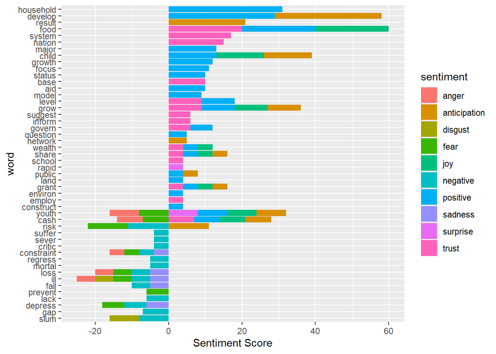

```r
# visualisation
v_word_count %>%
  filter(n > 3) %>%
  mutate(n = ifelse(sentiment %in% v_negative_emotions, -n, n))%>%
  mutate(word = reorder(word, n)) %>%
  ggplot(aes(word, n, fill = sentiment))+
  geom_col() +
  coord_flip() +
  labs(y = "Sentiment Score")
```

##### Regroupement des émotions positives et négatives dans les articles sur la pauvreté en Afrique

Dans cette étape, nous allons identifier et regrouper les émotions **positives** et **négatives** présentes dans les articles traitant de la pauvreté en Afrique en utilisant le dictionnaire **NRC**. Nous filtrerons les mots en fonction de ces émotions et calculerons leur fréquence pour évaluer la tonalité émotionnelle du corpus. Cette analyse nous permettra de mieux cerner les émotions dominantes dans les textes et leur impact sur la perception de la pauvreté en Afrique.

```r
v_text_sentiment <- v_tidy_data %>%
  inner_join(get_sentiments(v_lexicon)) %>%
  count(word, index = row_number() %/% 40, sentiment) %>%
  mutate(v_original_n = n) %>%
  mutate(v_positive_negative = ifelse(sentiment %in% v_positive_emotions, 'positive', 'negative')) %>%
  mutate(v_original_sentiment = sentiment) %>%
  spread(sentiment, n, fill = 0)


v_text_sentiment <- v_text_sentiment %>%
  mutate(positive = ifelse("positive" %in% colnames(v_text_sentiment), positive, 0)) %>%
  mutate(joy = ifelse("joy" %in% colnames(v_text_sentiment), joy, 0))%>%
  mutate(surprise = ifelse("surprise" %in% colnames(v_text_sentiment), surprise, 0)) %>%
  mutate(trust = ifelse("trust" %in% colnames(v_text_sentiment), trust, 0)) %>%
  mutate(anticipation = ifelse("anticipation" %in% colnames(v_text_sentiment), anticipation, 0)) %>%
  mutate(negative = ifelse("negative" %in% colnames(v_text_sentiment), negative, 0)) %>%
  mutate(anger = ifelse("anger" %in% colnames(v_text_sentiment), anger, 0)) %>%
  mutate(disgust = ifelse("disgust" %in% colnames(v_text_sentiment), disgust, 0)) %>%
  mutate(sadness = ifelse("sadness" %in% colnames(v_text_sentiment), sadness, 0)) %>%
  mutate(fear = ifelse("fear" %in% colnames(v_text_sentiment), fear,0)) %>%
  mutate(sentiment = (positive+joy+surprise+trust+anticipation)- (negative+anger+disgust+sadness+fear)) %>%
  ungroup()
```

##### Visualisation des contributions des mots

Pour mieux comprendre l’impact des mots dans les articles sur la pauvreté en Afrique, nous allons visualiser la contribution de chaque mot en fonction de son score émotionnel. Cette représentation graphique met en évidence les termes les plus marquants, permettant d’observer les tendances dominantes dans le corpus.

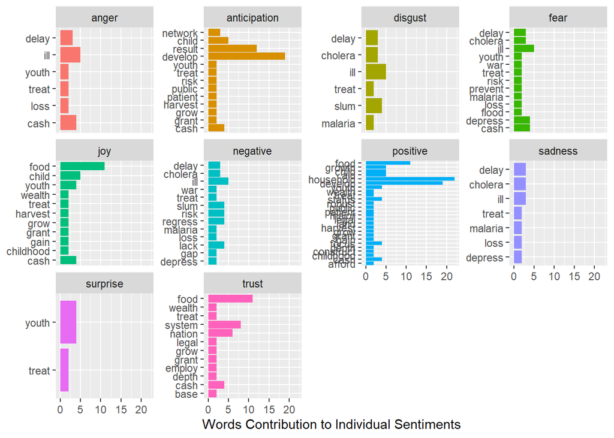

```r
v_text_sentiment %>%
  filter(v_original_n > 1) %>%
  group_by(v_original_sentiment) %>%
  top_n(10) %>%
  ungroup() %>%
  mutate(word = reorder(word, v_original_n)) %>%
  ggplot(aes(word, v_original_n, fill = v_original_sentiment)) +
  geom_col(show.legend = FALSE) +
  facet_wrap(~v_original_sentiment, scales = "free_y") +
  labs(y = "Words Contribution to Individual Sentiments", x = NULL) +
  coord_flip()
```

##### Visualisation des sentiments sous forme de nuage de mots

Nous allons maintenant visualiser les émotions associées aux mots dans les articles sur la pauvreté en Afrique sous forme de nuage de mots. Cette approche permet de mettre en évidence les mots les plus fréquents associés à chaque émotion, facilitant ainsi l’interprétation des émotions présentes dans le corpus. Les mots sont colorés en fonction de leur sentiment, offrant une vue d’ensemble des tendances émotionnelles.

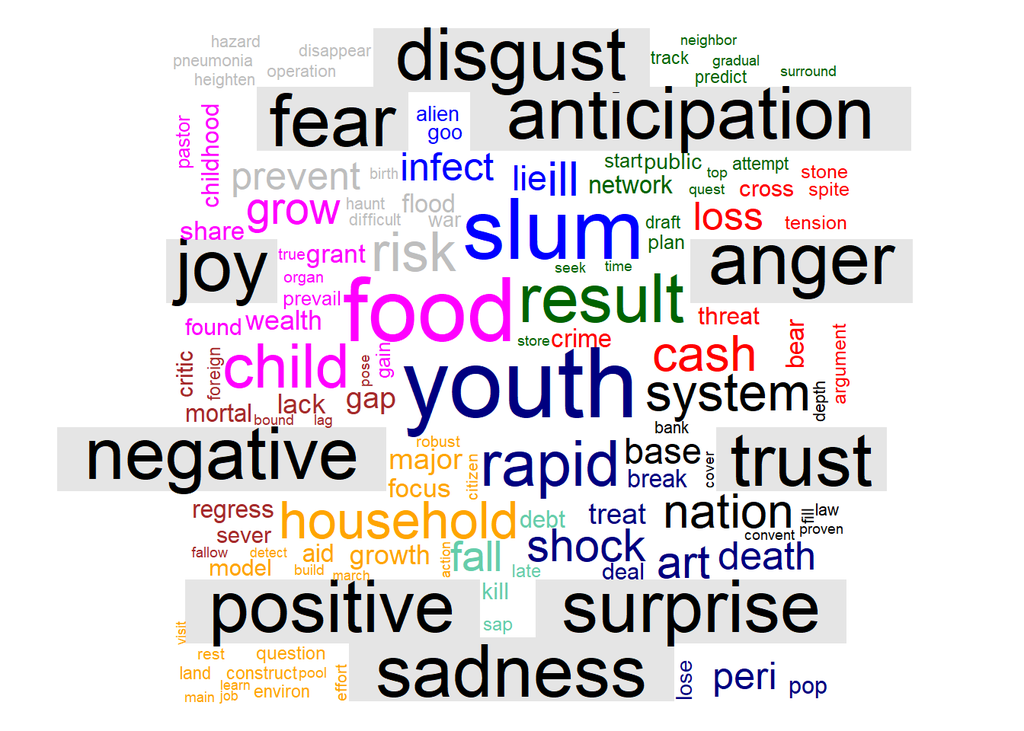

```r
# comparaison dans le nuage de mots

v_tidy_data %>%
  inner_join(get_sentiments(v_lexicon)) %>%
  count(word, sentiment, sort = TRUE) %>%
  acast(word ~ sentiment, value.var = "n", fill = 0) %>%
  comparison.cloud(
    colors = c("red", "dark green", "blue", "grey", "magenta", "brown",
               "orange", "mediumaquamarine", "navy"), max.words = 300)
```

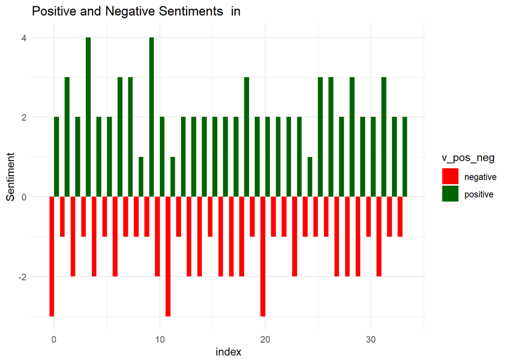

```r
# le flow de sentiment

v_text_nrc <- v_text_sentiment %>%
  mutate(v_pos_neg = ifelse(v_original_sentiment %in% v_positive_emotions, "positive", "negative")) %>%
  mutate(v_original_n = ifelse(v_pos_neg == "negative", -v_original_n, v_original_n))



ggplot(data = v_text_nrc, aes(x = index, y = v_original_n, fill = v_pos_neg)) +
  geom_bar(stat = 'identity', position = position_dodge()) +
  theme_minimal() +
  ylab("Sentiment") +
  ggtitle("Positive and Negative Sentiments  in") +
  scale_color_manual(values = c("red", "dark green")) +
  scale_fill_manual(values = c("red", "dark green"))
```

```r
# pour trouver l'emotion qui prevaut dans le text

v_emotions <- v_text_nrc %>%
  select(index, anger, anticipation, disgust, fear, joy, sadness, surprise, trust)

v_emotions <- v_text_nrc %>%
  select(index, anger, anticipation, disgust, fear, joy, sadness, surprise, trust) %>%
  melt(id = "index")

v_emotions <- v_text_nrc %>%
  select(index, anger, anticipation, disgust, fear, joy, sadness, surprise, trust) %>%
  melt(id = "index") %>%
  rename(linenumber = index, sentiment = variable, value = value)


v_emotions_group <- group_by(v_emotions, sentiment)

v_by_emotions <- summarise(v_emotions_group, values=sum(value))

v_temp <- v_by_emotions %>%
  mutate_if(is.factor, as.character)


v_temp <- v_by_emotions %>%
  mutate_if(is.factor, as.character)


ifelse(nrow(subset(v_temp, values == max(values))) == 1,
       unname(unlist(subset(v_temp, values == max(values)))),
       "No Prevalent Emotion")
```

[1] “disgust”

```r
subset(v_temp, values == max(values))
```

# A tibble: 1 × 2

sentiment values 1 disgust 1129

### Analyse des bigrammes

Avant d’explorer les relations entre les mots, nous passons à l’analyse des bigrammes. Cette approche permet d’identifier les paires de mots les plus couramment utilisées ensemble dans les articles traitant de la pauvreté en Afrique. Cela offre une meilleure compréhension du contexte et des associations lexicales présentes dans le texte.

L’analyse des bigrammes permet d’identifier les associations de mots les plus fréquentes dans les résumés d’articles sur la pauvreté en Afrique. En supprimant les mots vides, nous obtenons des expressions significatives qui révèlent des tendances et des concepts clés abordés dans le corpus.

```r
# Tokenisation des bigrammes :
# Nous divisons le texte en séquences de deux mots (bigrammes)
v_text_bigrams <- v_text %>%
  unnest_tokens(bigram, all_abstracts, token = "ngrams", n = 2)


# Séparation des bigrammes :
# Nous séparons chaque bigramme en deux colonnes distinctes (word1 et word2)
v_bigrams_separated <- v_text_bigrams %>%
  separate(bigram, c("word1", "word2"), sep = " ")

# Suppression des bigrammes contenant des mots vides (stop words) :
# Nous filtrons les bigrammes pour supprimer ceux contenant des mots vides
# dans l'une ou l'autre des deux colonnes
v_bigrams_filtered <- v_bigrams_separated %>%
  filter(!(word1 %in% stop_words$word)) %>%
  filter(!(word2 %in% stop_words$word))



# Comptage des bigrammes les plus fréquents :
# Nous comptons les occurrences de chaque bigramme restant dans le corpus
v_bigram_counts <- v_bigrams_filtered %>%
  count(word1, word2, sort = TRUE)

# Affichage des bigrammes les plus fréquents
head(v_bigram_counts, 10)
```

```
 word1       word2  n
```

1 90 2 saharan africa 43 3 south africa 28 4 south africa’s 17 5 mental health 10 6 income countries 9 7 poverty alleviation 9 8 south african 9 9 middle income 8 10 africa ssa 7

##### Visualisation des paires de mots les plus utilisés

```r
# Chargement des bibliothèques nécessaires pour la création et la visualisation de graphes
library(igraph)   # Permet de créer et manipuler des graphes
library(ggraph)   # Extension de ggplot2 pour visualiser des graphes

# Création du graphe à partir des bigrammes les plus fréquents
v_bigram_graph <- v_bigram_counts %>%
  filter(n > 3) %>%
  graph_from_data_frame()  # Convertir la table en objet graphe (nœuds = mots, liens = bigrammes)

# Affichage de l'objet graphe (structure du réseau de bigrammes)
v_bigram_graph
```

IGRAPH 62286b3 DN– 29 22 – + attr: name (v/c), n (e/n) + edges from 62286b3 (vertex names): [1] NA ->NA saharan ->africa  
[3] south ->africa south ->africa’s  
[5] mental ->health income ->countries  
[7] poverty ->alleviation south ->african  
[9] middle ->income africa ->ssa  
[11] poverty ->reduction cash ->transfer  
[13] food ->insecurity low ->income  
[15] population ->growth developing ->countries  
+ … omitted several edges

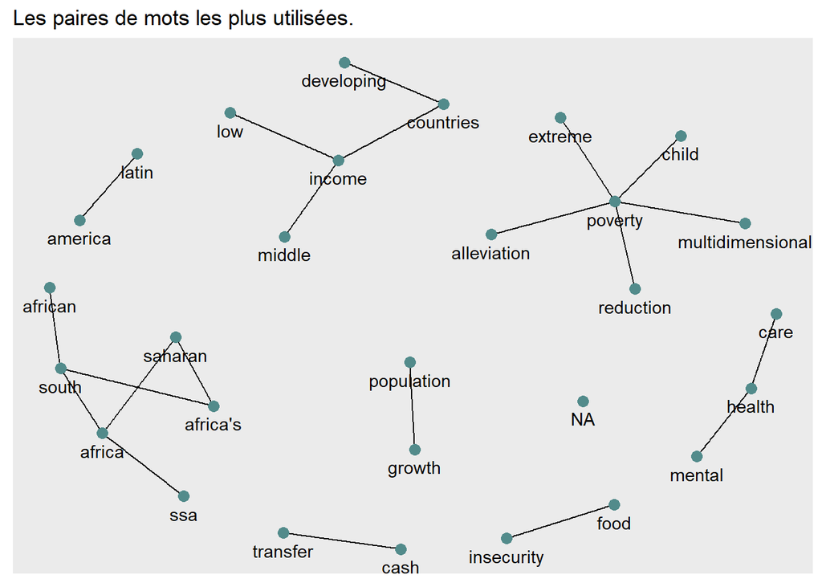

```r
# Définition du graphe avec un layout optimisé
set.seed(2020)  # Fixe une graine aléatoire pour assurer la reproductibilité du graphe

# Création et visualisation du graphe des bigrammes
ggraph(v_bigram_graph, layout = "kk") +  # Utilisation du layout Kamada-Kawai pour un positionnement optimal des nœuds
  geom_edge_link() +  # Ajoute les liens entre les mots pour représenter les bigrammes
  geom_node_point(color = "darkslategray4", size = 3) +
  geom_node_text(aes(label = name), vjust = 1.8) +
  ggtitle("Les paires de mots les plus utilisées. ")
```

**Le graphe des bigrammes met en évidence les associations les plus fréquentes entre les mots du texte. On observe des relations clés comme “population - growth”, “insecurity - food”, “mental - health” et “health - care”, qui soulignent des thèmes récurrents liés au développement, à la santé et à la sécurité alimentaire. De même, les liens “poverty - multidimensional”, “poverty - child” et “poverty - extreme” reflètent des préoccupations autour de la pauvreté sous différentes formes.**

**Par ailleurs, les connexions “income - countries”, “income - middle”, “income - low” et “countries - developing” mettent en lumière des distinctions économiques et des classifications des pays en fonction de leur niveau de revenu. Enfin, des associations géographiques comme “Africa - South”, “Africa - SSA”, “Latin - America” ou encore “Africa’s - Sahara” montrent un intérêt marqué pour les dynamiques socio-économiques propres à ces régions.**  
**Ces résultats permettent d’identifier les thématiques dominantes du corpus et les relations fortes entre certains concepts.**

### Application du Topic Modeling avec LDA

Dans cette étape, nous appliquons un modèle de **topic modeling** en utilisant la méthode **Latent Dirichlet Allocation (LDA)**. L’objectif est de découvrir les principaux sujets qui émergent des articles traitant de la pauvreté en Afrique. Cette approche permet d’identifier des groupes de mots qui apparaissent fréquemment ensemble et ainsi d’extraire des thèmes dominants dans l’ensemble des documents.

##### Détermination du choix du nombre de sujets.

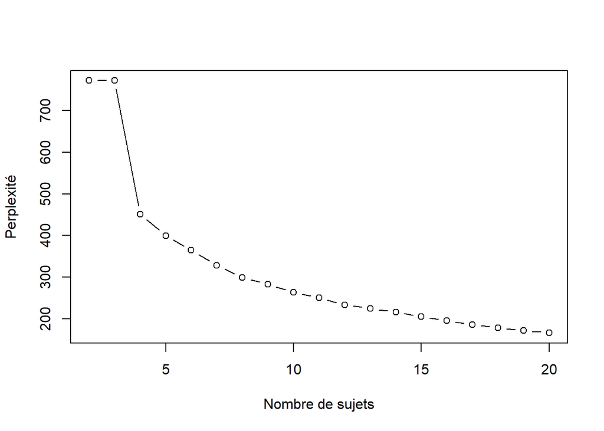

```r
library(tidytext)
library(topicmodels)

# Créer une matrice DTM depuis les données tidy
v_dtm <- v_tidy_data %>%
  count(linenumber, word) %>%
  cast_dtm(linenumber, word, n)

# Tester plusieurs nombres de sujets
perplexities <- sapply(2:20, function(k) {
  model <- LDA(v_dtm, k = k, control = list(seed = 1234))
  perplexity(model)
})

# Visualisation de la perplexité
plot(2:20, perplexities, type = "b", xlab = "Nombre de sujets", ylab = "Perplexité")
```

##### Sélection des sujets

```r
lda_model <- LDA(v_dtm, k = 3, control = list(seed = 1234))
terms(lda_model, 10)
```

```
  Topic 1     Topic 2   Topic 3
```

[1,] “south” “south” “health” [2,] “countri” “econom” “studi”  
[3,] “polici” “live” “saharan” [4,] “health” “social” “africa” [5,] “saharan” “studi” “effect” [6,] “develop” “countri” “develop” [7,] “africa” “educ” “urban”  
[8,] “examin” “world” “data”  
[9,] “household” “incom” “popul”  
[10,] “african” “saharan” “food”

```r
ap_topics <- tidy(lda_model, matrix = "beta")
```

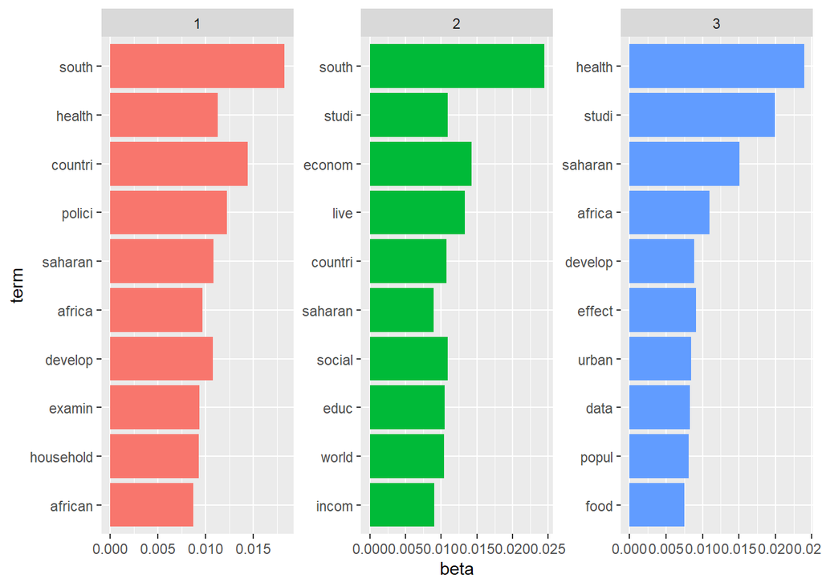

```r
 ap_top_terms <- ap_topics %>%
 group_by(topic) %>%
 top_n(10, beta) %>%
 ungroup() %>%
 arrange(topic, -beta)
 ap_top_terms %>%
 mutate(term = reorder(term, beta)) %>%
 ggplot(aes(term, beta, fill = factor(topic))) +
 geom_col(show.legend = FALSE) +
 facet_wrap(~ topic, scales = "free") +
 coord_flip()
```

## Interprétation générale des sujets :

**Topic 1** : Ce sujet semble être principalement axé sur les **questions géographiques**, **politiques** et **socio-économiques** liées à l’Afrique, en particulier dans des régions comme l’Afrique du Sud et le Sahara. Des mots comme “south”, “africa”, “saharan” et “polici” (probablement pour “policy”, politique) suggèrent que ce sujet pourrait concerner des discussions sur les **politiques publiques** en Afrique, avec un focus spécifique sur des problématiques **sociopolitiques** dans les régions méridionales de l’Afrique. Les termes comme “health” et “develop” indiquent également un lien avec des **initiatives de développement** et de **santé publique**.

**Topic 2** : Ce sujet semble centré sur des **aspects économiques** et **sociaux**, avec un accent sur les **inégalités** et les **conditions de vie** dans différents pays. Des termes tels que “econom”, “live”, “incom” (revenu), “countri” et “social” suggèrent une analyse des défis socio-économiques rencontrés par les **populations urbaines et rurales**, avec un focus particulier sur les **inégalités économiques** et les **politiques sociales**. Ce sujet pourrait discuter des **réformes économiques** ou des **programmes d’aide** en lien avec le revenu et la pauvreté.

**Topic 3** : Ce sujet semble être lié aux **problématiques de santé publique**, aux **conditions alimentaires** et aux **conditions de vie** en Afrique, avec un accent sur la santé, la **malnutrition** et les **données démographiques**. Des mots comme “health”, “food”, “africa”, “saharan”, “develop”, “urban” et “popul” indiquent que ce sujet pourrait concerner des **études d’impact sur la santé publique**, des **initiatives de nutrition** ou des **défis alimentaires** dans des zones urbaines ou sahariennes. Il se peut également que ce sujet soit lié aux **problématiques sanitaires** dans les **zones sahariennes** d’Afrique, où les **conditions climatiques et géographiques** exacerbent les défis de santé.